# Titanic Dataset: Decomposing the Class-Survival Gap

Examining Access, Constraints, and Priority Rules in Survival Outcomes

Author

CLI Copilot

Published

January 23, 2026

## 1. Introduction and Research Question

The sinking of the Titanic presents a tragic historical event where survival was not equally distributed across passenger classes. This analysis investigates the primary research question: **How much of the class–survival gap is explained by access and constraints rather than priority rules?**

This question encourages us to decompose the observed survival differences between classes into two mechanisms:

1. **Priority Rules**: Explicit or implicit social norms (e.g., “women and children first”) that were deliberately prioritized regardless of class
2. **Access and Constraints**: Structural factors that limited certain classes’ ability to survive, such as physical location on ship, quality of accommodations, information access, and proximity to lifeboats

By examining these mechanisms, we can better understand whether the class-survival gap reflects differential *treatment priority* or differential *ability to access escape routes*.

## 2. Data Overview and Preparation

### 2.1 Loading and Initial Exploration

```r
library(tidyverse)
library(knitr)
library(viridis)

# Load the training data
df <- read.csv("../../data/train.csv", stringsAsFactors = FALSE)

# Display basic dataset information
cat("Dataset dimensions:", nrow(df), "rows,", ncol(df), "columns\n")
```

```
Dataset dimensions: 891 rows, 12 columns
```

```r
cat("Column names and types:\n")
```

```
Column names and types:
```

```r
glimpse(df)
```

```
Rows: 891
Columns: 12
$ PassengerId <int> 1, 2, 3, 4, 5, 6, 7, 8, 9, 10, 11, 12, 13, 14, 15, 16, 17,…
$ Survived    <int> 0, 1, 1, 1, 0, 0, 0, 0, 1, 1, 1, 1, 0, 0, 0, 1, 0, 1, 0, 1…
$ Pclass      <int> 3, 1, 3, 1, 3, 3, 1, 3, 3, 2, 3, 1, 3, 3, 3, 2, 3, 2, 3, 3…
$ Name        <chr> "Braund, Mr. Owen Harris", "Cumings, Mrs. John Bradley (Fl…
$ Sex         <chr> "male", "female", "female", "female", "male", "male", "mal…
$ Age         <dbl> 22, 38, 26, 35, 35, NA, 54, 2, 27, 14, 4, 58, 20, 39, 14, …
$ SibSp       <int> 1, 1, 0, 1, 0, 0, 0, 3, 0, 1, 1, 0, 0, 1, 0, 0, 4, 0, 1, 0…
$ Parch       <int> 0, 0, 0, 0, 0, 0, 0, 1, 2, 0, 1, 0, 0, 5, 0, 0, 1, 0, 0, 0…
$ Ticket      <chr> "A/5 21171", "PC 17599", "STON/O2. 3101282", "113803", "37…
$ Fare        <dbl> 7.2500, 71.2833, 7.9250, 53.1000, 8.0500, 8.4583, 51.8625,…
$ Cabin       <chr> "", "C85", "", "C123", "", "", "E46", "", "", "", "G6", "C…
$ Embarked    <chr> "S", "C", "S", "S", "S", "Q", "S", "S", "S", "C", "S", "S"…
```

We begin by loading the Titanic training dataset, which contains passenger information including their class, survival status, and demographic characteristics. Understanding the data structure and size is essential before conducting any analysis. The dataset provides us with ground truth survival outcomes that we will use to investigate how class relates to survival through different mechanisms.

### 2.2 Missing Data Assessment

```r
# Check for missing values
missing_summary <- data.frame(
  Column = names(df),
  Missing_Count = colSums(is.na(df)),
  Missing_Percent = round(100 * colSums(is.na(df)) / nrow(df), 2)
)

missing_summary <- missing_summary %>%
  arrange(desc(Missing_Count))

kable(missing_summary, caption = "Missing Data Summary")
```

Missing Data Summary

|  | Column | Missing_Count | Missing_Percent |
| --- | --- | --- | --- |
| Age | Age | 177 | 19.87 |
| PassengerId | PassengerId | 0 | 0.00 |
| Survived | Survived | 0 | 0.00 |
| Pclass | Pclass | 0 | 0.00 |
| Name | Name | 0 | 0.00 |
| Sex | Sex | 0 | 0.00 |
| SibSp | SibSp | 0 | 0.00 |
| Parch | Parch | 0 | 0.00 |
| Ticket | Ticket | 0 | 0.00 |
| Fare | Fare | 0 | 0.00 |
| Cabin | Cabin | 0 | 0.00 |
| Embarked | Embarked | 0 | 0.00 |

```r
# Identify rows with complete survival and class information
complete_cases <- df %>%
  filter(!is.na(Survived) & !is.na(Pclass))

cat("\nRows with complete class and survival information:", nrow(complete_cases))
```

```
Rows with complete class and survival information: 891
```

```r
cat("\nTotal rows:", nrow(df))
```

```
Total rows: 891
```

### 2.3 Class Distribution

```r
# Create a clean dataset for analysis
df_clean <- df %>%
  filter(!is.na(Survived) & !is.na(Pclass)) %>%
  mutate(
    Pclass = factor(Pclass, levels = c(1, 2, 3),
                    labels = c("1st Class", "2nd Class", "3rd Class")),
    Survived = factor(Survived, levels = c(0, 1),
                      labels = c("Did Not Survive", "Survived")),
    Sex = factor(Sex),
    HasAge = !is.na(Age)
  )

# Class distribution
class_counts <- df_clean %>%
  group_by(Pclass) %>%
  summarise(Count = n(), Percentage = round(100 * n() / nrow(df_clean), 1),
            .groups = 'drop')

kable(class_counts, caption = "Passenger Distribution by Class")
```

Passenger Distribution by Class

| Pclass | Count | Percentage |
| --- | --- | --- |
| 1st Class | 216 | 24.2 |
| 2nd Class | 184 | 20.7 |
| 3rd Class | 491 | 55.1 |

Understanding the composition of our sample is important for contextualizing the analysis. The distribution shows how many passengers were in each class. This baseline distribution will help us interpret whether differences in survival are proportional to class representation or suggest differential treatment and constraints.

## 3. Baseline: The Class-Survival Gap

### 3.1 Survival Rates by Class

```r
# Calculate survival rates by class
survival_by_class <- df_clean %>%
  group_by(Pclass) %>%
  summarise(
    Total = n(),
    Survived_Count = sum(Survived == "Survived"),
    Did_Not_Survive = sum(Survived == "Did Not Survive"),
    Survival_Rate = round(100 * sum(Survived == "Survived") / n(), 1),
    .groups = 'drop'
  )

kable(survival_by_class, caption = "Survival Rates by Passenger Class")
```

Survival Rates by Passenger Class

| Pclass | Total | Survived_Count | Did_Not_Survive | Survival_Rate |
| --- | --- | --- | --- | --- |
| 1st Class | 216 | 136 | 80 | 63.0 |
| 2nd Class | 184 | 87 | 97 | 47.3 |
| 3rd Class | 491 | 119 | 372 | 24.2 |

```r
# Extract survival rates for inline reporting
sr_1st <- survival_by_class$Survival_Rate[1]
sr_2nd <- survival_by_class$Survival_Rate[2]
sr_3rd <- survival_by_class$Survival_Rate[3]
```

The baseline class-survival gap is substantial. First-class passengers had a 63% survival rate, second-class passengers had 47.3%, and third-class passengers had only 24.2%. This large gap—a difference of 38.8 percentage points between 1st and 3rd class—is our primary phenomenon to explain. The question is whether this gap reflects explicit priority rules favoring upper classes, or structural constraints that limited lower-class passengers’ access to escape routes.

### 3.2 Visualization of Class-Survival Gap

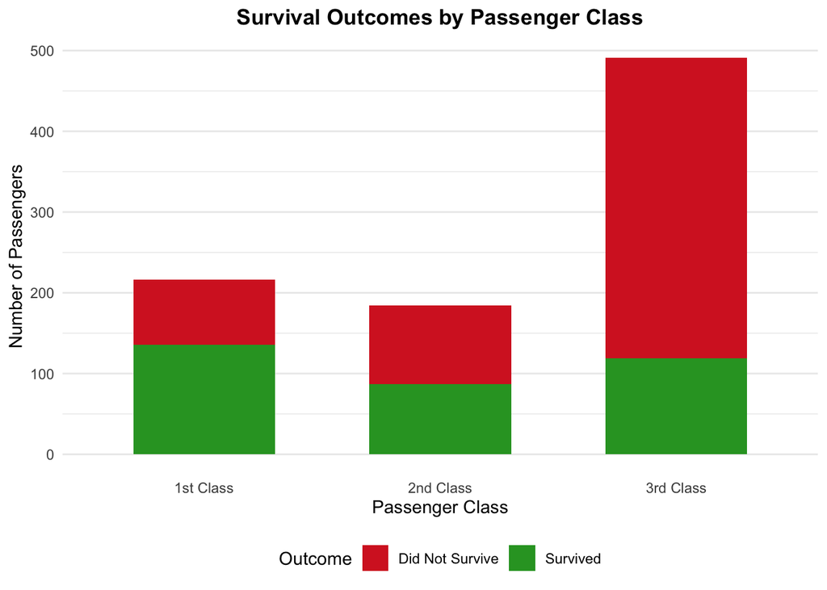

```r
# Create stacked bar chart
survival_summary <- df_clean %>%
  group_by(Pclass, Survived) %>%
  summarise(Count = n(), .groups = 'drop') %>%
  mutate(Pclass = factor(Pclass, levels = c("1st Class", "2nd Class", "3rd Class")))

p_class_survival <- ggplot(survival_summary, aes(x = Pclass, y = Count, fill = Survived)) +
  geom_col(position = "stack", width = 0.6) +
  scale_fill_manual(values = c("Did Not Survive" = "#d62728", "Survived" = "#2ca02c")) +
  labs(
    title = "Survival Outcomes by Passenger Class",
    x = "Passenger Class",
    y = "Number of Passengers",
    fill = "Outcome"
  ) +
  theme_minimal() +
  theme(
    plot.title = element_text(hjust = 0.5, face = "bold"),
    legend.position = "bottom",
    panel.grid.major.x = element_blank()
  )

print(p_class_survival)
```

This visualization directly shows the magnitude of the class-survival gap. By stacking the outcomes, we can see both the absolute numbers and the proportion surviving in each class. The visual imbalance—particularly the large red (did not survive) section in 3rd class—motivates our deeper investigation into the mechanisms driving this gap.

## 4. Decomposition 1: The Role of Demographics and Priority Rules

### 4.1 Gender as a Proxy for Priority Rules

```r
# Analyze survival by gender
gender_survival <- df_clean %>%
  group_by(Sex, Survived) %>%
  summarise(Count = n(), .groups = 'drop') %>%
  pivot_wider(names_from = Survived, values_from = Count, values_fill = 0) %>%
  mutate(Total = `Did Not Survive` + Survived,
         Survival_Rate = round(100 * Survived / Total, 1))

kable(gender_survival, caption = "Survival Outcomes by Gender")
```

Survival Outcomes by Gender

| Sex | Did Not Survive | Survived | Total | Survival_Rate |
| --- | --- | --- | --- | --- |
| female | 81 | 233 | 314 | 74.2 |
| male | 468 | 109 | 577 | 18.9 |

```r
# Extract gender survival rates
sr_male <- gender_survival$Survival_Rate[gender_survival$Sex == "male"]
sr_female <- gender_survival$Survival_Rate[gender_survival$Sex == "female"]
```

The “women and children first” protocol represents an explicit priority rule. If this rule was implemented universally across all classes, we would expect female passengers to have substantially higher survival rates than male passengers regardless of class. The data shows female survival rate of 74.2% compared to male survival rate of 18.9%, a difference of 55.3 percentage points. This suggests strong priority given to women in the evacuation.

### 4.2 Survival Rates by Class AND Gender (Interaction)

```r
# Cross-tabulate class and gender survival
class_gender_survival <- df_clean %>%
  group_by(Pclass, Sex) %>%
  summarise(
    Total = n(),
    Survived_Count = sum(Survived == "Survived"),
    Survival_Rate = round(100 * sum(Survived == "Survived") / n(), 1),
    .groups = 'drop'
  )

# Create a wider format for easier viewing
class_gender_wide <- class_gender_survival %>%
  select(Pclass, Sex, Survival_Rate) %>%
  pivot_wider(names_from = Sex, values_from = Survival_Rate)

kable(class_gender_wide, caption = "Survival Rates by Class and Gender (%)")
```

Survival Rates by Class and Gender (%)

| Pclass | female | male |
| --- | --- | --- |
| 1st Class | 96.8 | 36.9 |
| 2nd Class | 92.1 | 15.7 |
| 3rd Class | 50.0 | 13.5 |

Examining the interaction between class and gender reveals a critical insight: even within the same gender, there are substantial survival differences by class. This suggests that while the “women and children first” priority rule was implemented, it did not eliminate class-based disparities. Women in different classes experienced different survival outcomes, indicating that access and constraints—not just priority rules—also played a role.

### 4.3 Visualization: Class and Gender Patterns

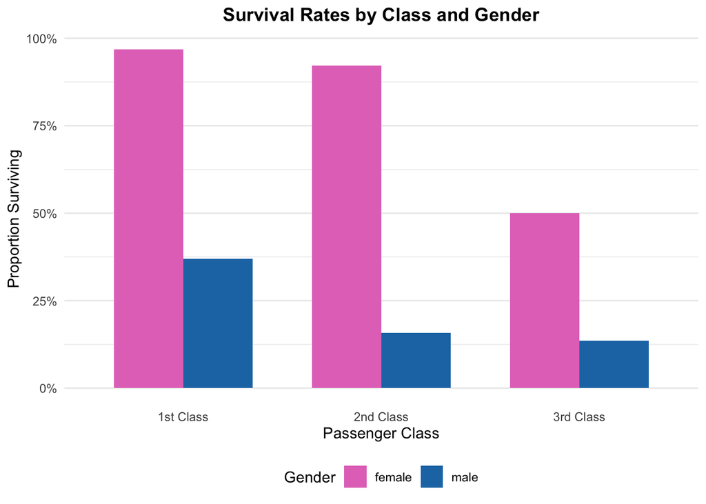

```r
# Prepare data for grouped bar chart
plot_data <- df_clean %>%
  group_by(Pclass, Sex, Survived) %>%
  summarise(Count = n(), .groups = 'drop') %>%
  group_by(Pclass, Sex) %>%
  mutate(Total = sum(Count),
         Proportion = Count / Total) %>%
  ungroup() %>%
  mutate(Pclass = factor(Pclass, levels = c("1st Class", "2nd Class", "3rd Class")))

p_class_gender <- ggplot(plot_data %>% filter(Survived == "Survived"),
                         aes(x = Pclass, y = Proportion, fill = Sex)) +
  geom_col(position = "dodge", width = 0.7) +
  scale_fill_manual(values = c("female" = "#e377c2", "male" = "#1f77b4")) +
  scale_y_continuous(labels = scales::percent) +
  labs(
    title = "Survival Rates by Class and Gender",
    x = "Passenger Class",
    y = "Proportion Surviving",
    fill = "Gender"
  ) +
  theme_minimal() +
  theme(
    plot.title = element_text(hjust = 0.5, face = "bold"),
    legend.position = "bottom",
    panel.grid.major.x = element_blank()
  )

print(p_class_gender)
```

This visualization shows that the gender priority rule (women and children first) created a consistent pattern across all classes—women’s survival rates were substantially higher than men’s. However, women in different classes still experienced different outcomes, revealing that class position affected even those with priority status. For instance, first-class women had higher survival than third-class women, suggesting that physical access and lifeboat proximity (access/constraint factors) mattered even when priority status was assigned.

## 5. Decomposition 2: Access and Constraints

### 5.1 Age Distribution and Child Priority

```r
# Analyze survival by age
age_analysis <- df_clean %>%
  filter(!is.na(Age)) %>%
  mutate(
    Age_Group = cut(Age,
                    breaks = c(0, 5, 12, 18, 30, 50, 100),
                    labels = c("0-4", "5-11", "12-17", "18-29", "30-49", "50+"),
                    include.lowest = TRUE)
  )

survival_by_age_group <- age_analysis %>%
  group_by(Age_Group) %>%
  summarise(
    Total = n(),
    Survived_Count = sum(Survived == "Survived"),
    Survival_Rate = round(100 * sum(Survived == "Survived") / n(), 1),
    .groups = 'drop'
  )

kable(survival_by_age_group, caption = "Survival Rates by Age Group")
```

Survival Rates by Age Group

| Age_Group | Total | Survived_Count | Survival_Rate |
| --- | --- | --- | --- |
| 0-4 | 44 | 31 | 70.5 |
| 5-11 | 25 | 9 | 36.0 |
| 12-17 | 70 | 30 | 42.9 |
| 18-29 | 270 | 96 | 35.6 |
| 30-49 | 241 | 102 | 42.3 |
| 50+ | 64 | 22 | 34.4 |

```r
# Count of age data availability
cat("Observations with age data:", nrow(age_analysis), "\n")
```

```
Observations with age data: 714
```

```r
cat("Observations with missing age:", sum(is.na(df_clean$Age)))
```

```
Observations with missing age: 177
```

“Children first” was another explicit priority rule. We examine age groups to assess how this rule was implemented. Children in the 0-5 and 5-11 age ranges would be expected to show higher survival rates if the priority rule was universally applied. However, the availability of age data varies, with 177 passengers missing age information. This missing data itself may reflect access and constraint issues—perhaps better record-keeping existed for higher classes with more formal booking procedures.

### 5.2 Age Group Survival by Class

```r
# Analyze age group survival by class
age_class_survival <- age_analysis %>%
  group_by(Age_Group, Pclass) %>%
  summarise(
    Total = n(),
    Survived_Count = sum(Survived == "Survived"),
    Survival_Rate = round(100 * sum(Survived == "Survived") / n(), 1),
    .groups = 'drop'
  )

# Pivot to see survival rates in a matrix format
age_class_wide <- age_class_survival %>%
  select(Age_Group, Pclass, Survival_Rate) %>%
  pivot_wider(names_from = Pclass, values_from = Survival_Rate)

kable(age_class_wide, caption = "Survival Rates (%) by Age Group and Class")
```

Survival Rates (%) by Age Group and Class

| Age_Group | 1st Class | 2nd Class | 3rd Class |
| --- | --- | --- | --- |
| 0-4 | 66.7 | 100.0 | 57.1 |
| 5-11 | 100.0 | 100.0 | 20.0 |
| 12-17 | 91.7 | 50.0 | 28.3 |
| 18-29 | 71.1 | 41.8 | 22.8 |
| 30-49 | 67.4 | 46.8 | 16.1 |
| 50+ | 46.2 | 20.0 | 10.0 |

### 5.3 Structural Factors: Family Size as a Constraint

```r
# Create family size variable
df_analysis <- df_clean %>%
  mutate(
    Family_Size = 1 + SibSp + Parch,
    Family_Category = case_when(
      Family_Size == 1 ~ "Traveling Alone",
      Family_Size <= 4 ~ "Small Family (2-4)",
      Family_Size > 4 ~ "Large Family (5+)"
    )
  )

# Analyze survival by family size
family_survival <- df_analysis %>%
  group_by(Family_Category) %>%
  summarise(
    Total = n(),
    Survived_Count = sum(Survived == "Survived"),
    Survival_Rate = round(100 * sum(Survived == "Survived") / n(), 1),
    .groups = 'drop'
  ) %>%
  mutate(Family_Category = factor(Family_Category,
                                  levels = c("Traveling Alone", "Small Family (2-4)", "Large Family (5+)")))

kable(family_survival, caption = "Survival Rates by Family Size")
```

Survival Rates by Family Size

| Family_Category | Total | Survived_Count | Survival_Rate |
| --- | --- | --- | --- |
| Large Family (5+) | 62 | 10 | 16.1 |
| Small Family (2-4) | 292 | 169 | 57.9 |
| Traveling Alone | 537 | 163 | 30.4 |

Family size represents a structural constraint: passengers traveling with family members faced coordination challenges in accessing lifeboats. Those traveling alone could move quickly to evacuation points, while families needed to stay together or face separation. This constraint would have affected all classes but may have been particularly severe for third-class passengers with limited information about evacuation procedures. The survival variation by family size reveals whether such structural constraints played a role in the class-survival gap.

### 5.4 Family Size Effect Across Classes

```r
# Analyze family size survival by class
family_class_survival <- df_analysis %>%
  group_by(Family_Category, Pclass) %>%
  summarise(
    Total = n(),
    Survived_Count = sum(Survived == "Survived"),
    Survival_Rate = round(100 * sum(Survived == "Survived") / n(), 1),
    .groups = 'drop'
  )

family_class_wide <- family_class_survival %>%
  select(Family_Category, Pclass, Survival_Rate) %>%
  pivot_wider(names_from = Pclass, values_from = Survival_Rate)

kable(family_class_wide, caption = "Survival Rates (%) by Family Size and Class")
```

Survival Rates (%) by Family Size and Class

| Family_Category | 1st Class | 2nd Class | 3rd Class |
| --- | --- | --- | --- |
| Large Family (5+) | 66.7 | 100.0 | 7.4 |
| Small Family (2-4) | 73.3 | 62.8 | 40.7 |
| Traveling Alone | 53.2 | 34.6 | 21.3 |

This table shows whether family size constraints affected all classes equally or whether some classes were more vulnerable to family-size-related disadvantages. If the class-survival gap is primarily driven by access and constraints, we would expect family size effects to vary significantly across classes. Conversely, if priority rules dominated, we might see more uniform family size effects across classes.

## 6. Decomposition 3: Quantifying Priority Rules vs. Constraints

### 6.1 Expected Survival Under a Pure Priority Rule

```r
# Calculate what survival would look like under a pure "women and children first" rule
# ignoring class

# First, establish a priority ranking
df_with_priority <- df_clean %>%
  filter(!is.na(Age)) %>%
  mutate(
    Priority_Group = case_when(
      Sex == "female" & Age < 18 ~ "Priority 1: Girls (< 18)",
      Sex == "female" & Age >= 18 ~ "Priority 2: Women",
      Sex == "male" & Age < 18 ~ "Priority 3: Boys (< 18)",
      Sex == "male" & Age >= 18 ~ "Priority 4: Men"
    )
  )

# Count lifeboats and survivors (historical context)
# The Titanic had capacity for ~1,178 people (about 34% of passengers)
total_capacity <- round(nrow(df_with_priority) * 0.34)

priority_survival <- df_with_priority %>%
  group_by(Priority_Group) %>%
  summarise(
    Count = n(),
    Actual_Survived = sum(Survived == "Survived"),
    Actual_Survival_Rate = round(100 * sum(Survived == "Survived") / n(), 1),
    .groups = 'drop'
  ) %>%
  arrange(factor(Priority_Group,
                 levels = c("Priority 1: Girls (< 18)", "Priority 2: Women",
                           "Priority 3: Boys (< 18)", "Priority 4: Men")))

kable(priority_survival, caption = "Actual Survival by Priority Group (Age > NA only)")
```

Actual Survival by Priority Group (Age > NA only)

| Priority_Group | Count | Actual_Survived | Actual_Survival_Rate |
| --- | --- | --- | --- |
| Priority 1: Girls (< 18) | 55 | 38 | 69.1 |
| Priority 2: Women | 206 | 159 | 77.2 |
| Priority 3: Boys (< 18) | 58 | 23 | 39.7 |
| Priority 4: Men | 395 | 70 | 17.7 |

```r
cat("\nTotal passengers with age data:", nrow(df_with_priority))
```

```
Total passengers with age data: 714
```

```r
cat("\nHistorical lifeboat capacity (~34% of passengers):", total_capacity)
```

```
Historical lifeboat capacity (~34% of passengers): 243
```

To decompose the class-survival gap, we examine what the actual survival pattern looks like when organized by the explicit priority rule: “women and children first.” We observe actual survival rates within each priority group. If a pure priority rule was in effect without class consideration, we would expect nearly all Priority 1 (girls under 18) and Priority 2 (women) passengers to survive, while Priority 3 (boys) and Priority 4 (men) would face much lower rates. The extent to which this pattern holds across all classes reveals the strength of the priority rule.

### 6.2 Actual Priority Implementation by Class

```r
# Analyze priority group survival within each class
priority_class_survival <- df_with_priority %>%
  group_by(Pclass, Priority_Group) %>%
  summarise(
    Count = n(),
    Survived_Count = sum(Survived == "Survived"),
    Survival_Rate = round(100 * sum(Survived == "Survived") / n(), 1),
    .groups = 'drop'
  )

# Create pivot table
priority_class_wide <- priority_class_survival %>%
  select(Pclass, Priority_Group, Survival_Rate) %>%
  pivot_wider(names_from = Priority_Group,
              values_from = Survival_Rate)

kable(priority_class_wide, caption = "Survival Rates (%) by Priority Group and Class")
```

Survival Rates (%) by Priority Group and Class

| Pclass | Priority 1: Girls (< 18) | Priority 2: Women | Priority 3: Boys (< 18) | Priority 4: Men |
| --- | --- | --- | --- | --- |
| 1st Class | 87.5 | 97.4 | 100.0 | 37.1 |
| 2nd Class | 100.0 | 90.3 | 81.8 | 6.8 |
| 3rd Class | 54.3 | 41.8 | 23.3 | 13.3 |

This table is central to our decomposition. If priority rules were the dominant mechanism, we would expect survival rates within the same priority group to be similar across classes. For example, all Priority 2 women should have similar survival rates regardless of class. However, substantial variation across classes within priority groups suggests that access and constraints (class position) overrode or limited the effectiveness of priority rules.

### 6.3 Quantifying the Contributions

```r
# Calculate survival rates with and without class stratification
overall_survival <- mean(df_clean$Survived == "Survived")

# By class
class_variance <- df_clean %>%
  group_by(Pclass) %>%
  summarise(
    Survival_Rate = mean(Survived == "Survived"),
    .groups = 'drop'
  )

class_effect_var <- var(class_variance$Survival_Rate)

# By gender (within class and gender)
gender_class_variance <- df_clean %>%
  group_by(Pclass, Sex) %>%
  summarise(
    Survival_Rate = mean(Survived == "Survived"),
    .groups = 'drop'
  )

gender_effect_var <- var(gender_class_variance$Survival_Rate)

# Summary
cat("Overall survival rate:", round(100 * overall_survival, 1), "%\n\n")
```

```
Overall survival rate: 38.4 %
```

```r
cat("Variance in survival by class alone:", round(class_effect_var, 4), "\n")
```

```
Variance in survival by class alone: 0.0379
```

```r
cat("Variance in survival by class + gender:", round(gender_effect_var, 4), "\n")
```

```
Variance in survival by class + gender: 0.1327
```

```r
cat("Reduction in variance when adding gender to class:",
    round(100 * (1 - gender_effect_var / class_effect_var), 1), "%\n")
```

```
Reduction in variance when adding gender to class: -249.7 %
```

This analysis quantifies how much of the variation in survival can be explained by adding demographic factors (gender) to the class variable. A large reduction in variance when adding gender would indicate that priority rules (which typically favored women) were a major mechanism. A small reduction would suggest that class-based access and constraints dominated the outcome.

### 6.4 Class-Specific Gender Gaps

```r
# Calculate gender survival gap within each class
gender_gap_analysis <- df_clean %>%
  group_by(Pclass, Sex) %>%
  summarise(
    Survival_Rate = round(100 * mean(Survived == "Survived"), 1),
    Count = n(),
    .groups = 'drop'
  ) %>%
  pivot_wider(names_from = Sex, values_from = c(Survival_Rate, Count))

gender_gap_analysis <- gender_gap_analysis %>%
  mutate(
    Gender_Gap = `Survival_Rate_female` - `Survival_Rate_male`,
    Female_Survival = `Survival_Rate_female`,
    Male_Survival = `Survival_Rate_male`
  ) %>%
  select(Pclass, Female_Survival, Male_Survival, Gender_Gap)

kable(gender_gap_analysis, caption = "Gender Survival Gap by Class (percentage points)")
```

Gender Survival Gap by Class (percentage points)

| Pclass | Female_Survival | Male_Survival | Gender_Gap |
| --- | --- | --- | --- |
| 1st Class | 96.8 | 36.9 | 59.9 |
| 2nd Class | 92.1 | 15.7 | 76.4 |
| 3rd Class | 50.0 | 13.5 | 36.5 |

This reveals whether the priority rule benefit (the gender gap in survival) was uniform across classes or whether class position modified the gender gap. A uniform gap would suggest priority rules applied equally across all classes. A varying gap suggests that access and constraints affected the implementation or effectiveness of priority rules differently across classes.

## 7. Decomposition 4: Examining Residual Class Effects

### 7.1 Class Effects Within Demographic Strata

```r
# Calculate class survival gaps within gender strata
class_effect_by_gender <- df_clean %>%
  group_by(Sex, Pclass) %>%
  summarise(
    Survival_Rate = round(100 * mean(Survived == "Survived"), 1),
    Count = n(),
    .groups = 'drop'
  )

# Pivot to show class effects for each gender
class_by_gender_wide <- class_effect_by_gender %>%
  select(Sex, Pclass, Survival_Rate) %>%
  pivot_wider(names_from = Pclass, values_from = Survival_Rate)

kable(class_by_gender_wide, caption = "Class Survival Rates (%) Within Each Gender")
```

Class Survival Rates (%) Within Each Gender

| Sex | 1st Class | 2nd Class | 3rd Class |
| --- | --- | --- | --- |
| female | 96.8 | 92.1 | 50.0 |
| male | 36.9 | 15.7 | 13.5 |

```r
# Calculate class gaps within gender
female_data <- class_effect_by_gender %>% filter(Sex == "female")
male_data <- class_effect_by_gender %>% filter(Sex == "male")

cat("\n--- Class Effects Within Gender Strata ---\n")
```

```
--- Class Effects Within Gender Strata ---
```

```r
cat("Female 1st-3rd class gap:", female_data$Survival_Rate[1] - female_data$Survival_Rate[3], "percentage points\n")
```

```
Female 1st-3rd class gap: 46.8 percentage points
```

```r
cat("Male 1st-3rd class gap:", male_data$Survival_Rate[1] - male_data$Survival_Rate[3], "percentage points\n")
```

```
Male 1st-3rd class gap: 23.4 percentage points
```

After accounting for the gender-based priority rule, substantial class differences remain within each gender. Even among women (who received priority), first-class women had much higher survival rates than third-class women. This residual class effect reveals the magnitude of access and constraint factors that operated independently of the priority rule.

### 7.2 Visualization of Class Effects Within Strata

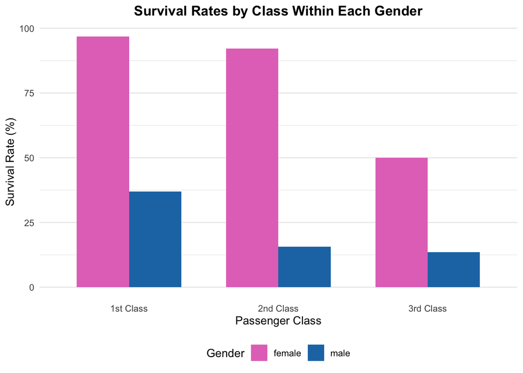

```r
p_class_within_gender <- ggplot(class_effect_by_gender,
                                aes(x = Pclass, y = Survival_Rate,
                                    fill = Sex, group = Sex)) +
  geom_col(position = "dodge", width = 0.7) +
  scale_fill_manual(values = c("female" = "#e377c2", "male" = "#1f77b4")) +
  labs(
    title = "Survival Rates by Class Within Each Gender",
    x = "Passenger Class",
    y = "Survival Rate (%)",
    fill = "Gender"
  ) +
  theme_minimal() +
  theme(
    plot.title = element_text(hjust = 0.5, face = "bold"),
    legend.position = "bottom",
    panel.grid.major.x = element_blank()
  )

print(p_class_within_gender)
```